# 2026-02-25_hw01

Chris

2026-02-25

I did this homework in an R project, which cannot be uploaded onto canvas, therefore I sent all files to GitHub. The link is: https://github.com/ChrisW12372/2026-02-25_p8106-hw01.git

```r
library(tidyverse)
library(glmnet)
library(pls)
library(caret)

set.seed(202602)
```

# 1 Question a

## 1.1 Read the Data

```r
df_train <- read_csv("data/housing_training.csv") |>
  janitor::clean_names()
df_test <- read_csv("data/housing_test.csv") |>
  janitor::clean_names()
```

## 1.2 Make a Matrix

```r
y_train <- df_train$sale_price
y_test  <- df_test$sale_price

x_train <- model.matrix(sale_price ~ ., df_train)[, -1]
x_test  <- model.matrix(sale_price ~ ., df_test)[, -1]
```

## 1.3 LASSO

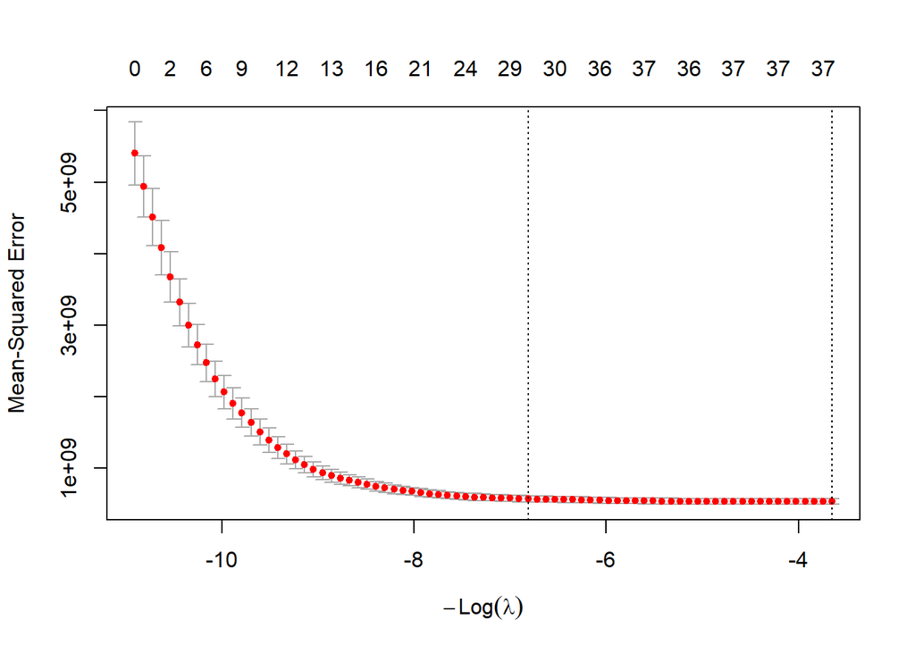

```r
cv_lasso <- cv.glmnet(
  x_train,
  y_train,
  alpha = 1
)

plot(cv_lasso)
```

```r
cv_lasso$lambda.min
```

```
## [1] 38.51706
```

```r
cv_lasso$lambda.1se
```

```
## [1] 910.7318
```

```r
pred_test <- predict(cv_lasso, s = "lambda.min", newx = x_test)

mse_test <- mean((y_test - pred_test)^2)

mse_test
```

```
## [1] 442720919
```

```r
coef_1se <- coef(cv_lasso, s = "lambda.1se")

sum(coef_1se != 0) - 1
```

```
## [1] 29
```

- The optimal tuning parameter selected by cross-validation is 38.5170586 and the testing MSE is 4.4272092^{8}.
- Using the 1SE rule, the selected tuning parameter is 910.7317737. Under this choice, 29 predictors are retained in the model (excluding the intercept).

# 2 Question b

```r
alphas <- seq(0.1, 0.9, by = 0.1)

cv_results <- list()

for (a in alphas) {

  cv_elastic <- cv.glmnet(
    x_train,
    y_train,
    alpha = a
  )

  cv_results[[as.character(a)]] <- cv_elastic
}

cv_errors <- sapply(cv_results, function(fit) min(fit$cvm))

cv_errors
```

```
##       0.1       0.2       0.3       0.4       0.5       0.6       0.7       0.8
## 544729336 535690766 541350022 531790519 536287888 537873950 529605407 540712946
##       0.9
## 531639348
```

```r
# choose the best alpha
best_alpha <- alphas[which.min(cv_errors)]
best_alpha
```

```
## [1] 0.7
```

```r
best_cv <- cv_results[[as.character(best_alpha)]]
best_lambda <- best_cv$lambda.min
best_lambda
```

```
## [1] 55.02437
```

```r
pred_elastic <- predict(best_cv, s = "lambda.min", newx = x_test)

mse_elastic <- mean((y_test - pred_elastic)^2)

mse_elastic
```

```
## [1] 442518091
```

- An elastic net model was fit using 10-fold cross-validation over a grid of alpha values ranging from 0.1 to 0.9. For each alpha, the optimal lambda was selected via cross-validation. The minimum cross-validation error was achieved at alpha = 0.7 with lambda = 55.0243695. The test MSE is 4.43 × 10^8, which is comparable to that obtained from LASSO.
- Since elastic net involves tuning two parameters, the 1SE rule is not applicable because the cross-validation error is defined over a two-dimensional grid rather than a single curve.

# 3 Question c

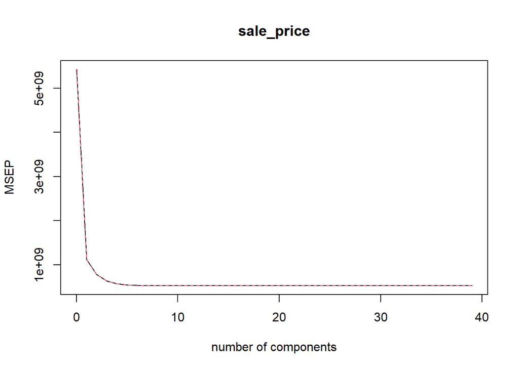

```r
pls_fit <- plsr(
  sale_price ~ .,
  data = df_train,
  scale = TRUE,
  validation = "CV"
)
validationplot(pls_fit, val.type = "MSEP")
```

```r
# find the best components
cv_mse <- RMSEP(pls_fit)$val[1, , -1]
best_ncomp <- which.min(cv_mse)
best_ncomp
```

```
## 12 comps
##       12
```

```r
# make predictions using best components
pred_pls <- predict(pls_fit, newdata = df_test, ncomp = best_ncomp)

mse_pls <- mean((y_test - pred_pls)^2)

mse_pls
```

```
## [1] 449622718
```

A partial least squares model was fit using 10-fold cross-validation to determine the optimal number of components. The minimum cross-validation error was achieved at 12 components. The test MSE is 4.4962272^{8}. The predictive performance is comparable to that of LASSO and elastic net.

# 4 Question d

Among the three models, LASSO and elastic net have nearly the same test errors, while PLS performs a little worse, therefore PLS is not an option. Based on the principle of parsimony, LASSO is preferred due to its simpler tuning procedure and its ability to perform variable selection. Therefore, LASSO is chosen as the final model for prediction.

# 5 Question e

```r
train_control <- trainControl(method = "cv", number = 10)

lasso_caret <- train(
  sale_price ~ .,
  data = df_train,
  method = "glmnet",
  trControl = train_control,
  tuneGrid = expand.grid(
    alpha = 1,
    lambda = seq(0.001, 1000, length = 100)
  )
)
lasso_caret$bestTune
```

```
##   alpha lambda
## 8     1 70.708
```

- To make a fair comparison for LASSO, I fixed alpha = 1 in caret and tuned only lambda. Under this setting, caret selected lambda = 70.708, which is close to `glmnet`’s 38.5170586.
- Small discrepancies between the tuning parameters selected by `caret` and `glmnet` are expected. Even when alpha is fixed at 1 for LASSO, the two packages may use different lambda grids, cross-validation folds, and preprocessing procedures. These implementation differences can lead to slightly different selected lambda values, although predictive performance is typically very similar.